GPH Geostatistics for  
Population Health

[figure not shown]

# Mapping disease risk with model-based geostatistics

An example deck for the GPH slide template

Claudio Fronterre

Senior Research Fellow in Statistical Science

Department of Applied Health Sciences  
University of Birmingham

c.fronterre@bham.ac.uk

GPH group meeting

10 November 2026

Birmingham, UK

## What this template gives you

- A title slide built from the YAML header, with the GPH wordmark and your logos
- Numbered section slides, statements and a closing slide, in light or dark
- Layouts for columns, key numbers, steps, cards, equations and code
- Outlines, full-bleed pictures, papers, people and QR codes
- A ggplot2 theme and colour scales that match the slides
- One self-contained HTML file that can also be printed to PDF

Write the content in Markdown. The extension takes care of the design.

## Outline

01Writing slidesText, emphasis, columns and statements

02Figures and dataPlots, maps, tables and colour keys

03Models and codeEquations, R code, callouts and references

# Writing slides

Text, emphasis, columns and statements

## Lead text and a key message

Start a slide with one sentence that says what the audience should take from it.

Body text is set at 28 pixels so that it can be read from the back of a lecture theatre. Use **bold** for key terms, a gold marker for the one phrase that matters most, and [links](https://quarto.org/docs/presentations/revealjs/) where the audience may want to read more.

A takeaway block closes the slide with the message to remember.

## Ways to mark a word

A gold marker for the phrase that matters most

A gold underline for a term you are about to define

A ring around one number, such as 95%

White on black for a label or a warning

The range scale parameter, for a word you are correcting

*Serif italics* for gentle emphasis

Write `[words]{.mark}`, `.underline`, `.circle` or `.invert`, `~~words~~` and `*words*`. Add `.fragment` to draw the mark on the next click, like this.

## Two columns

### Text and a figure

Columns take any width. Add `.v-center` to align their middles and `.divided` for a separating line.

Prevalence is higher where nearby surveys also found many positives.

Simulated survey of 120 villages.

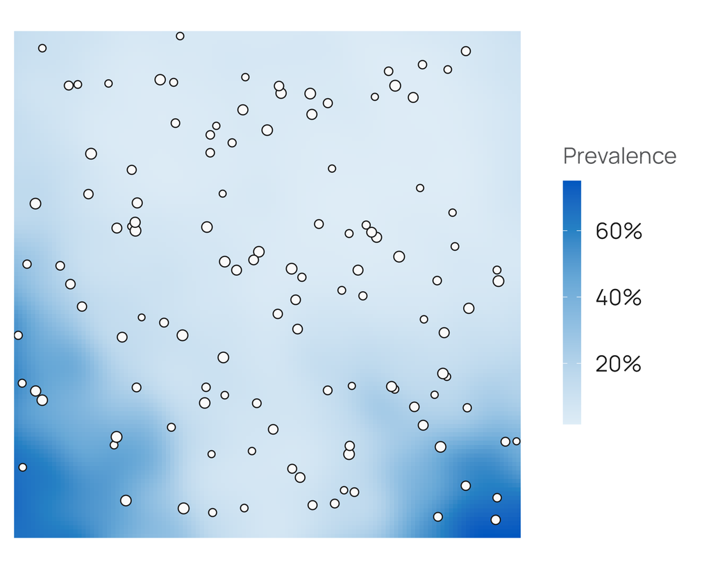

## Nearby surveys tell us about places we have not visited

Spatial correlation is what lets a geostatistical model borrow strength across locations.

## Key numbers

**120** villages surveyed

**14,191** people tested

**14%** average observed prevalence

Each paragraph inside `.stats` becomes one figure. The first bold text is set large. Use `.stats .large` for a single headline number.

Values are computed in R from the simulated data when the slides are rendered.

## A process in steps

1. **Explore the data** Look at the empirical variogram and the spatial pattern of residuals.
2. **Fit the model** Estimate covariate effects and the parameters of the spatial correlation.
3. **Check the predictions** Use cross-validation to compare predicted and observed prevalence.
4. **Report with uncertainty** Map predictive means alongside exceedance probabilities.

## Three ideas side by side

### Methods

New models for spatial and spatio-temporal health data, with honest uncertainty.

### Software

Open R packages, such as RiskMap, that make the methods usable by others.

### Applications

Work with health programmes on decisions about surveillance and control.

Add `.accent` to one card to give it a gold rule.

# Figures and data

Plots, maps, tables and colour keys

## The empirical variogram

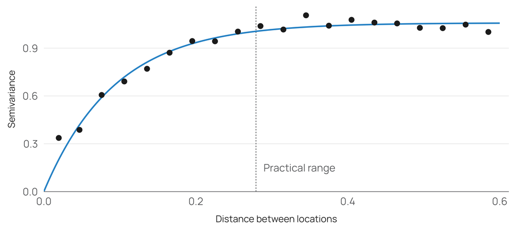

Simulated data at 400 locations. Points are binned empirical semivariances. The line is an exponential variogram fitted by weighted least squares, with estimated scale parameter 0.093 and practical range 0.28.

## A map beside its message

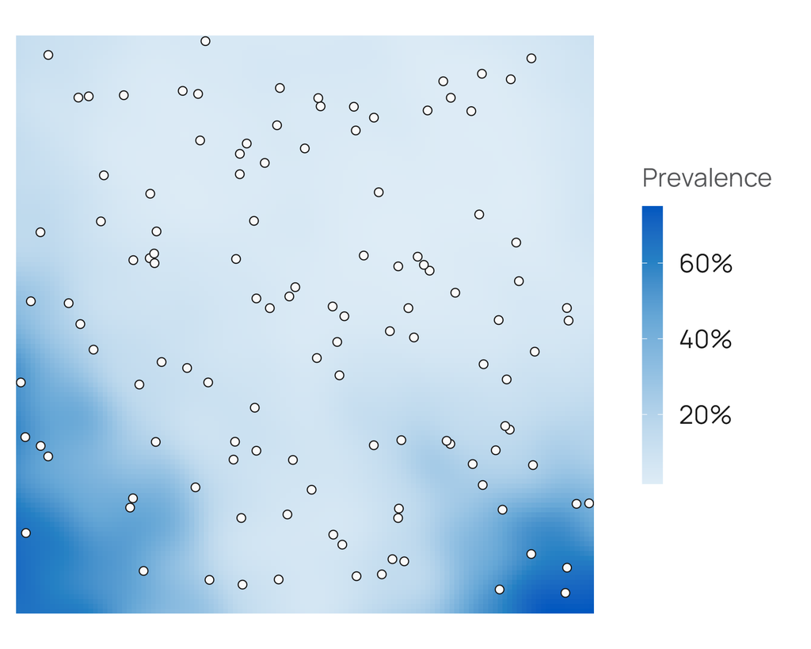

### Sequential colour for magnitude

`scale_fill_gph_c()` uses tints of the brand blue, from light for low values to deep for high values.

For signed quantities such as residuals, use `type = "diverging"`.

Simulated prevalence surface with survey locations.

## Three maps from one model

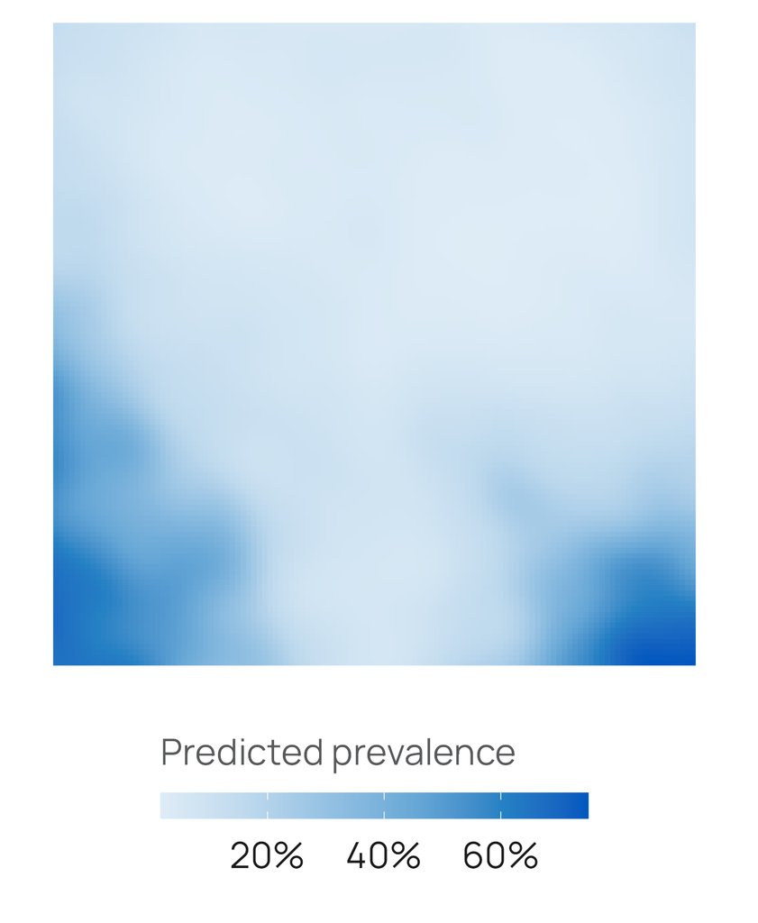

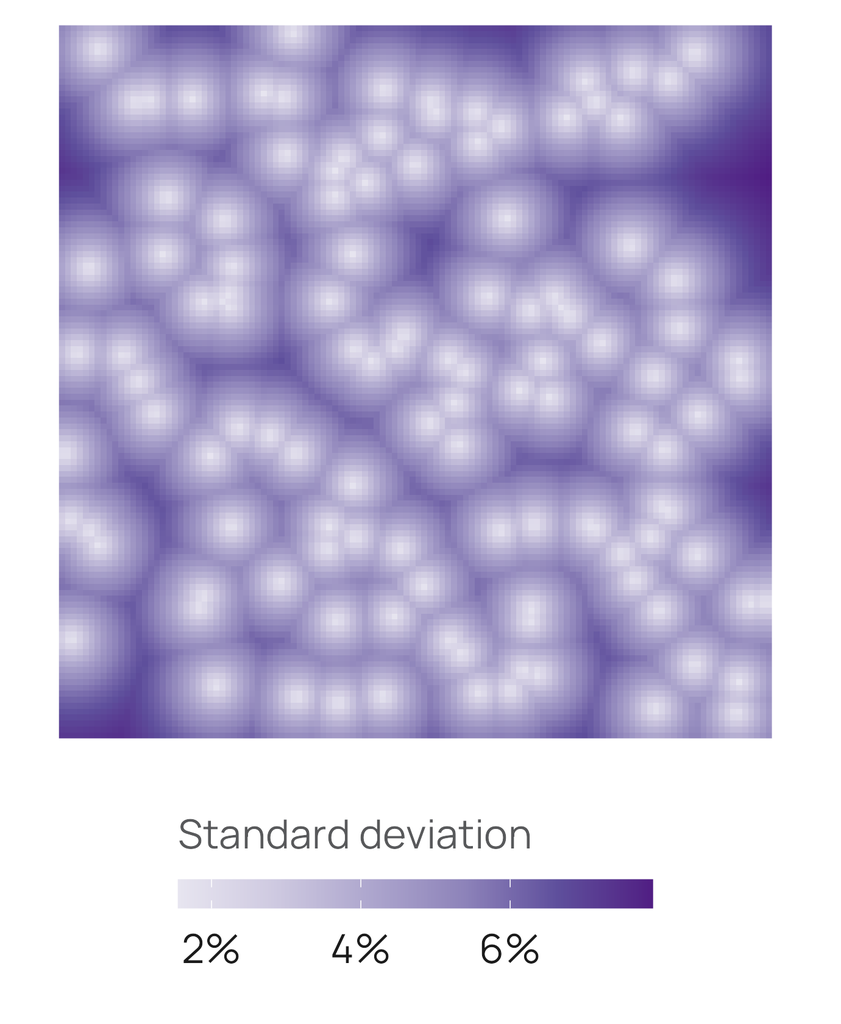

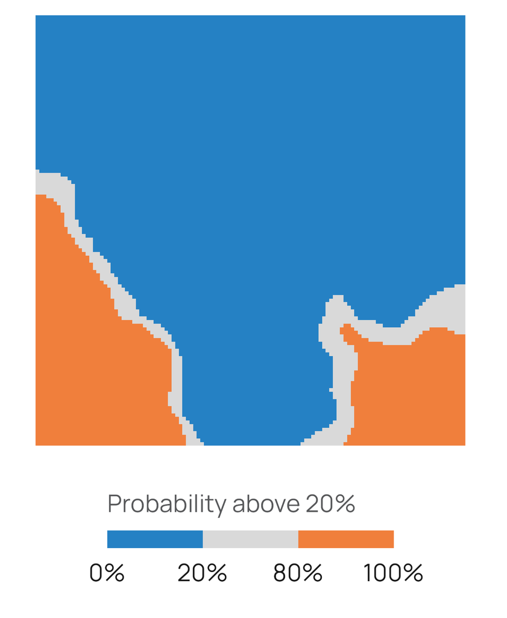

## Colour keys in the text

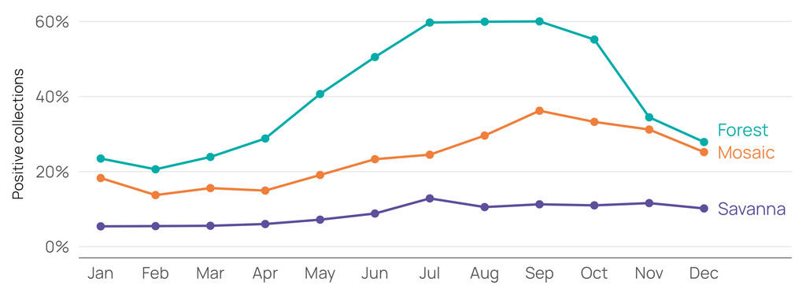

Write Forest, Mosaic and Savanna to link the text to the figure without coloured text, or tint a marker as in Forest. Add `.line` or `.dot` to change the key’s shape.

## One group in colour

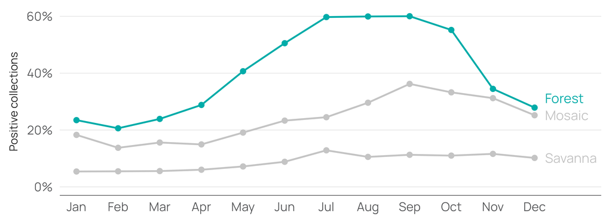

Only in Forest does positivity pass 40%. The other zones stay on the plot in grey, for context.

## Tables

| Question | Model output | Shown as |
| --- | --- | --- |
| Where is prevalence highest? | Predictive mean of prevalence | A map |
| How sure are we? | Predictive standard deviation | A second map with its own scale |
| Has a threshold been crossed? | Exceedance probability $P\{p(x) > c \mid y\}$ | A map on a fixed 0 to 1 scale |
| What is happening across a district? | Areal average with a predictive interval | A number with its interval |

Tables have clean rules and no shading. Keep them short and round the numbers.

## Where prevalence is highest

Simulated data. Replace the image with your own photo or map.

## Papers on a slide

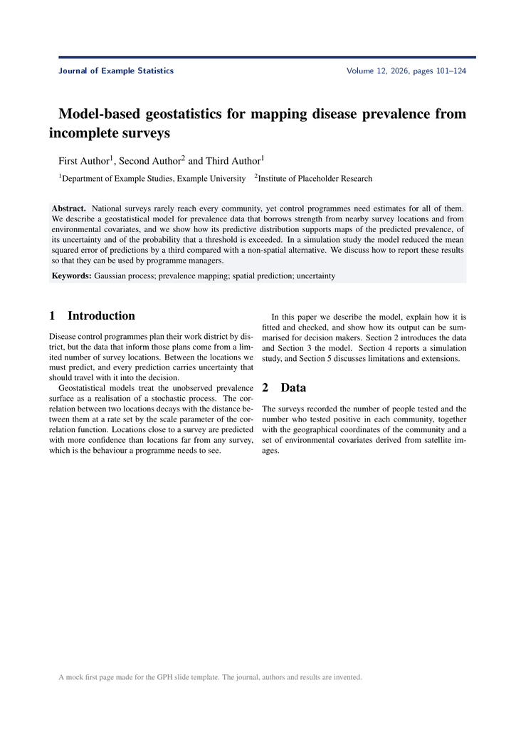

Journal of Example Statistics, 2026

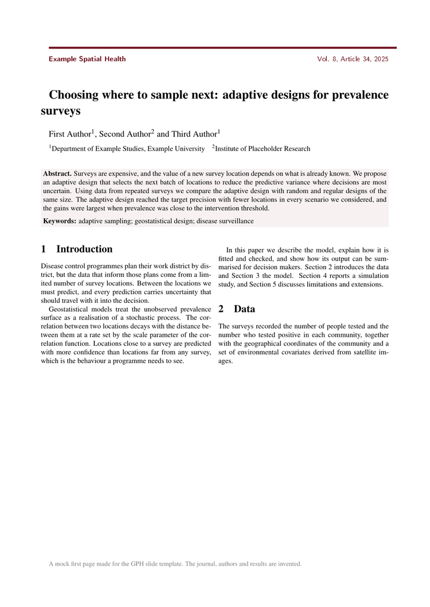

Example Spatial Health, 2025

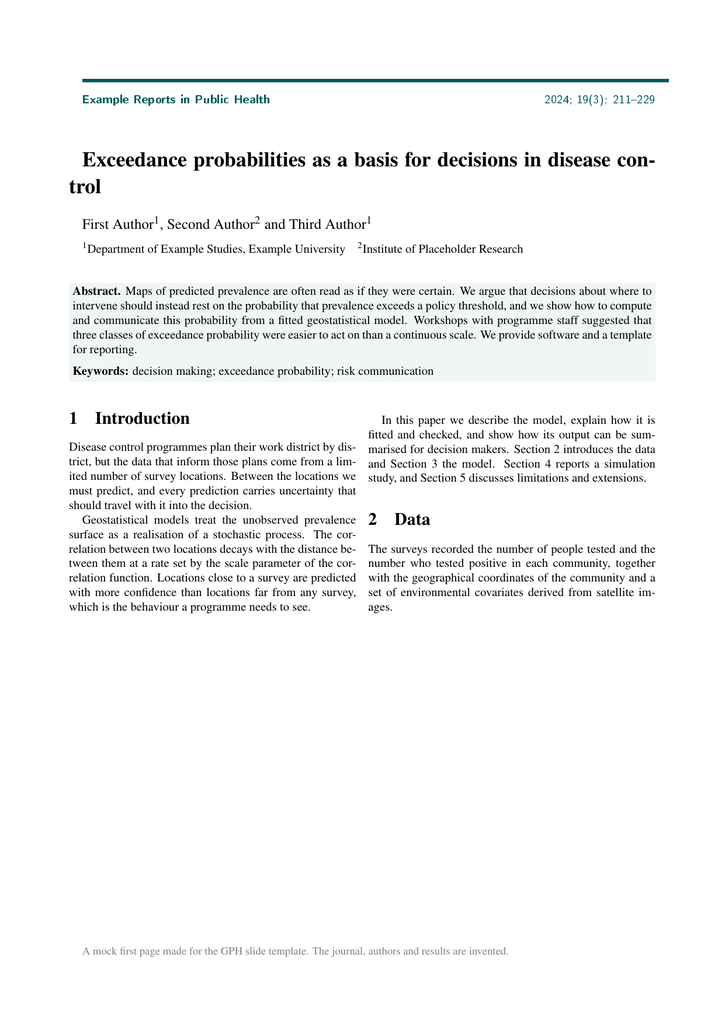

Example Reports in Public Health, 2024

## Three papers, one programme of work

Each study answered a question the previous one raised, from mapping prevalence to choosing where to survey next and deciding where to act.

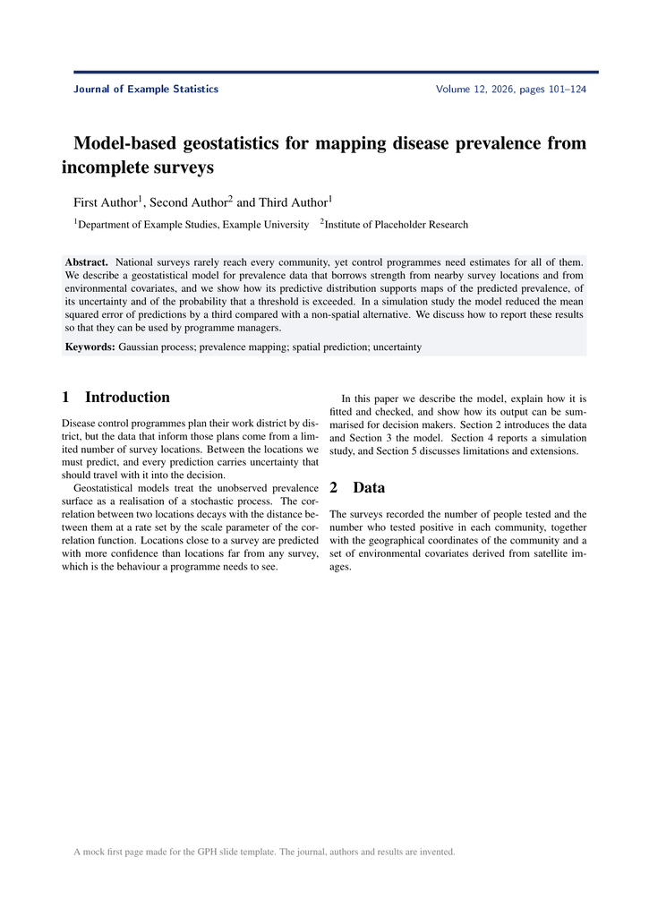

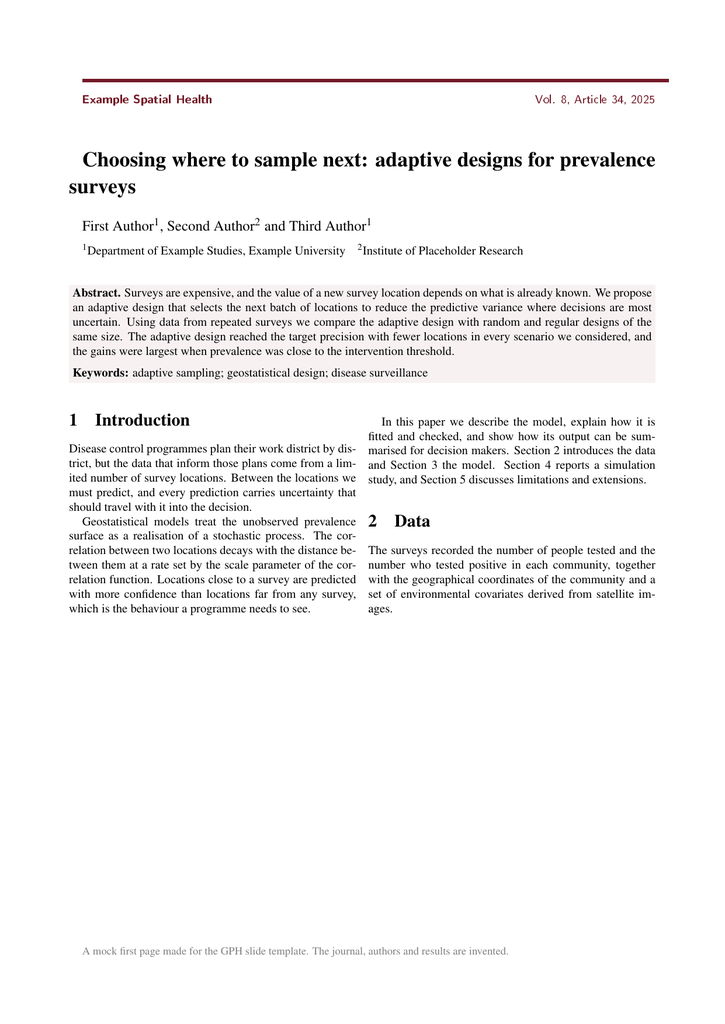

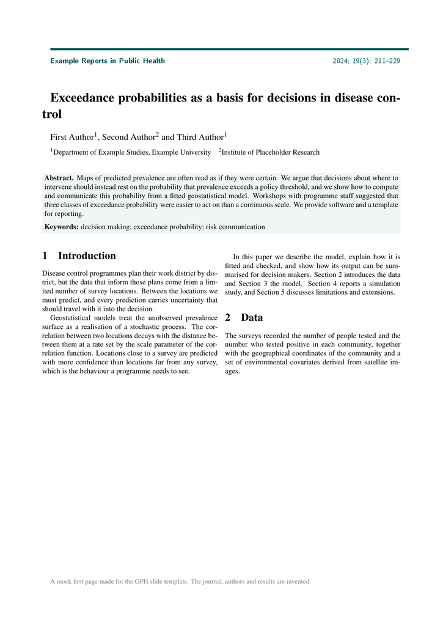

## Outline

01Writing slidesText, emphasis, columns and statements

02Figures and dataPlots, maps, tables and colour keys

03Models and codeEquations, R code, callouts and references

# Models and code

Equations, R code, callouts and references

## A model and what each term means

$$\log\left\{\frac{p(x_i)}{1 - p(x_i)}\right\} = d(x_i)^\top \beta + S(x_i) + Z_i$$

$Y_i \sim \text{Bin}\{n_i, p(x_i)\}$

Number of positive tests among $n_i$ people sampled at location $x_i$

$d(x_i)^\top \beta$

Effects of covariates such as elevation or rainfall

$S(x)$

Zero-mean Gaussian process with variance $\sigma^2$ and correlation $\rho(u) = \exp(-u / \phi)$

$\phi$

Scale parameter of the spatial correlation. The practical range is $\log(20)\,\phi \approx 3\phi$

$Z_i$

Unstructured variation, independent $\text{N}(0, \tau^2)$

## Code

```r
library(RiskMap)

data(loaloa)

fit <- glgpm(
  NO_INF ~ log(ELEVATION) + gp(),
  data = loaloa,
  family = "binomial",
  denominator = NO_EXAM,
  distance_units = "km"
)

summary(fit)
```

Set `echo: true` on a chunk to show its code. Add `code-line-numbers: "|1-3|5-11"` to step through the lines on each click.

## Code with its output

```r
summary(sites$observed)
```

```
   Min. 1st Qu.  Median    Mean 3rd Qu.    Max.
0.00000 0.04052 0.07976 0.13733 0.16146 0.72656
```

Output is set in grey beside a thin rule, so that it reads as a result rather than as code to type.

## Callouts

**About the data**

Survey locations are simulated and do not refer to real villages.

**Practical range**

For the exponential correlation it is about three times the scale parameter.

**Before sharing**

Check that every figure has a source line and that no personal data are shown.

## Revealing points one at a time

- Surveys are expensive, so we cannot visit every village
- Prevalence varies smoothly in space
- A model of that variation predicts where we have no data

Use `.incremental` for lists and `. . .` to pause anywhere else.

## A quotation

> All models are wrong, but some are useful.

> George E. P. Box, 1979

Quotations are set in the heading serif with a thin rule.

## Citations

Model-based geostatistics was introduced by Diggle et al. (1998). Book-length treatments are Diggle and Ribeiro Jr (2007) and Diggle and Giorgi (2019), and Giorgi and Fronterre (forthcoming) covers the methods in R.

Cite with `@key` from `references.bib`. Quarto formats the list on the references slide.

## A prevalence map without its uncertainty is only half an answer

Show predictive standard deviations or exceedance probabilities beside every map of predicted prevalence.

## Conclusions

- **Spatial models** borrow strength from nearby surveys
- **Uncertainty** belongs on the map, not in a footnote
- **Open software** lets programmes use the methods

End the talk on the message you want people to repeat.

## References

Diggle, Peter J., and Emanuele Giorgi. 2019. *Model-Based Geostatistics for Global Public Health: Methods and Applications*. Chapman & Hall/CRC. https://doi.org/10.1201/9781315188492.

Diggle, Peter J., and Paulo J. Ribeiro Jr. 2007. *Model-Based Geostatistics*. Springer. https://doi.org/10.1007/978-0-387-48536-2.

Diggle, Peter J., Jonathan A. Tawn, and R. A. Moyeed. 1998. “Model-Based Geostatistics.” *Journal of the Royal Statistical Society Series C: Applied Statistics* 47 (3): 299–350. https://doi.org/10.1111/1467-9876.00113.

Giorgi, Emanuele, and Claudio Fronterre. Forthcoming. *Model-Based Geostatistics for Global Public Health Using R*. Chapman & Hall/CRC. https://mbgr.org.

## People who shaped the field

- FNFlorence NightingaleStatistics for public health
- JSJohn SnowMapped cholera in London, 1854
- DKDanie KrigeKriging is named after him
- BMBertil MatérnThe Matérn correlation, 1960
- GMGeorges MatheronFounded geostatistics, 1962

## Thank you

**Claudio Fronterre**

c.fronterre@bham.ac.uk

mbgr.org

# Backup

Slides for questions

## Syntax at a glance

```markdown
## Slide title {.statement}

::: {.lead}
Opening sentence.
:::

::: {.takeaway}
Key message.
:::

[phrase]{.mark}
[term]{.underline .fragment}
[Forest]{.key .turquoise}

# Section {.dark}
```

```markdown
::: {.stats}
**676** trap locations

**7,617** site-months
:::

::: {.steps}
1. **Step** with a description
:::

::: {.cards}
::: {.card}
### Title
Text
:::
:::
```

## Slide classes

| Class | Use it on | Effect |
| --- | --- | --- |
| `.statement` | slide heading | One large message |
| `.closing` | slide heading | Closing slide with the motif |
| `.dark` | section, statement or closing slide | White on the brand black |
| `.photo` | slide heading | Background image fills the slide |
| `.outline` | slide heading | List of sections, filled in for you |
| `.no-title` | slide heading | Hides the title bar |
| `.unnumbered` | section heading | Section slide without a number |
| `.backup` | section heading | Starts the uncounted backup slides |

## Layout classes

| Class | Use it on | Effect |
| --- | --- | --- |
| `.fill` | div around one image | Image fills the space below the title |
| `.framed` | image | Thin border, for screenshots |
| `.logo-row` | div of images | Lines up partner or funder logos |
| `.caption`, `.small` | div or span | Grey metadata text |
| `.source` | div | Source line pinned to the bottom |
| `.papers` | div of images or PDFs | Tops of first pages, or `.full` pages |
| `.people` | div around a list | Grid of people with photos or initials |